# About Dataset

Data Source: https://www.kaggle.com/datasets/amirmotefaker/ab-testing-dataset

Below are all the features in the dataset:

- 'Campaign Name': The name of the campaign
- 'Date': Date of the record
- 'Spend': Amount spent on the campaign in dollars
- '# of Impressions': Number of impressions the ad crossed through the campaign
- 'Reach': The number of unique impressions received in the ad
- '# of Website Clicks': Number of website clicks received through the ads
- '# of Searches': Number of users who performed searches on the website
- '# of View Content': Number of users who viewed content and products on the website
- '# of Add to Cart': Number of users who added products to the cart
- '# of Purchase': Number of purchases

Two campaigns were performed by the company:

- Control Campaign
- Test Campaign

```python
%pip install pandas matplotlib seaborn scipy > nul
```

```python
import pandas as pd
import matplotlib.pyplot as plt
import matplotlib.colors as colors
import seaborn as sns
from scipy.stats import ttest_ind
from scipy.stats import zscore
import numpy as np
```

# Data Loading & Exploration

```python
df_control = pd.read_csv(r'C:\Users\ardac\Downloads\SQL Stuff\AB Test Dataset\control_group.csv', sep=';')
df_test = pd.read_csv(r'C:\Users\ardac\Downloads\SQL Stuff\AB Test Dataset\test_group.csv', sep=';')
```

```python
df_control.head()
```

|  | Campaign Name | Date | Spend [USD] | # of Impressions | Reach | # of Website Clicks | # of Searches | # of View Content | # of Add to Cart | # of Purchase |
| --- | --- | --- | --- | --- | --- | --- | --- | --- | --- | --- |
| 0 | Control Campaign | 1.08.2019 | 2280 | 82702.0 | 56930.0 | 7016.0 | 2290.0 | 2159.0 | 1819.0 | 618.0 |
| 1 | Control Campaign | 2.08.2019 | 1757 | 121040.0 | 102513.0 | 8110.0 | 2033.0 | 1841.0 | 1219.0 | 511.0 |
| 2 | Control Campaign | 3.08.2019 | 2343 | 131711.0 | 110862.0 | 6508.0 | 1737.0 | 1549.0 | 1134.0 | 372.0 |
| 3 | Control Campaign | 4.08.2019 | 1940 | 72878.0 | 61235.0 | 3065.0 | 1042.0 | 982.0 | 1183.0 | 340.0 |
| 4 | Control Campaign | 5.08.2019 | 1835 | NaN | NaN | NaN | NaN | NaN | NaN | NaN |

```python
df_test.head()
```

|  | Campaign Name | Date | Spend [USD] | # of Impressions | Reach | # of Website Clicks | # of Searches | # of View Content | # of Add to Cart | # of Purchase |
| --- | --- | --- | --- | --- | --- | --- | --- | --- | --- | --- |
| 0 | Test Campaign | 1.08.2019 | 3008 | 39550 | 35820 | 3038 | 1946 | 1069 | 894 | 255 |
| 1 | Test Campaign | 2.08.2019 | 2542 | 100719 | 91236 | 4657 | 2359 | 1548 | 879 | 677 |
| 2 | Test Campaign | 3.08.2019 | 2365 | 70263 | 45198 | 7885 | 2572 | 2367 | 1268 | 578 |
| 3 | Test Campaign | 4.08.2019 | 2710 | 78451 | 25937 | 4216 | 2216 | 1437 | 566 | 340 |
| 4 | Test Campaign | 5.08.2019 | 2297 | 114295 | 95138 | 5863 | 2106 | 858 | 956 | 768 |

```python
print('CONTROL')
print(f'Rows            : {df_control.shape[0]}')
print(f'Columns         : {df_control.shape[1]}')
print(f'Features        : {df_control.columns.tolist()}')
print(f'Missing Values  : {df_control.isnull().values.sum()}')
print(f'Unique Values   : \n\n{df_control.nunique()}')
print('- - - - - - - - - - - - - - - - - - - -')
print('TEST')
print(f'Rows            : {df_test.shape[0]}')
print(f'Columns         : {df_test.shape[1]}')
print(f'Features        : {df_test.columns.tolist()}')
print(f'Missing Values  : {df_test.isnull().values.sum()}')
print(f'Unique Values   : \n\n{df_test.nunique()}')
```

```
CONTROL
Rows            : 30
Columns         : 10
Features        : ['Campaign Name', 'Date', 'Spend [USD]', '# of Impressions', 'Reach', '# of Website Clicks', '# of Searches', '# of View Content', '# of Add to Cart', '# of Purchase']
Missing Values  : 7
Unique Values   :

Campaign Name           1
Date                   30
Spend [USD]            30
# of Impressions       29
Reach                  29
# of Website Clicks    29
# of Searches          29
# of View Content      26
# of Add to Cart       29
# of Purchase          28
dtype: int64
- - - - - - - - - - - - - - - - - - - -
TEST
Rows            : 30
Columns         : 10
Features        : ['Campaign Name', 'Date', 'Spend [USD]', '# of Impressions', 'Reach', '# of Website Clicks', '# of Searches', '# of View Content', '# of Add to Cart', '# of Purchase']
Missing Values  : 0
Unique Values   :

Campaign Name           1
Date                   30
Spend [USD]            30
# of Impressions       30
Reach                  30
# of Website Clicks    30
# of Searches          29
# of View Content      30
# of Add to Cart       30
# of Purchase          28
dtype: int64
```

```python
df_control.describe()
```

|  | Spend [USD] | # of Impressions | Reach | # of Website Clicks | # of Searches | # of View Content | # of Add to Cart | # of Purchase |
| --- | --- | --- | --- | --- | --- | --- | --- | --- |
| count | 30.000000 | 29.000000 | 29.000000 | 29.000000 | 29.000000 | 29.000000 | 29.000000 | 29.000000 |
| mean | 2288.433333 | 109559.758621 | 88844.931034 | 5320.793103 | 2221.310345 | 1943.793103 | 1300.000000 | 522.793103 |
| std | 367.334451 | 21688.922908 | 21832.349595 | 1757.369003 | 866.089368 | 777.545469 | 407.457973 | 185.028642 |
| min | 1757.000000 | 71274.000000 | 42859.000000 | 2277.000000 | 1001.000000 | 848.000000 | 442.000000 | 222.000000 |
| 25% | 1945.500000 | 92029.000000 | 74192.000000 | 4085.000000 | 1615.000000 | 1249.000000 | 930.000000 | 372.000000 |
| 50% | 2299.500000 | 113430.000000 | 91579.000000 | 5224.000000 | 2390.000000 | 1984.000000 | 1339.000000 | 501.000000 |
| 75% | 2532.000000 | 121332.000000 | 102479.000000 | 6628.000000 | 2711.000000 | 2421.000000 | 1641.000000 | 670.000000 |
| max | 3083.000000 | 145248.000000 | 127852.000000 | 8137.000000 | 4891.000000 | 4219.000000 | 1913.000000 | 800.000000 |

```python
df_test.describe()
```

|  | Spend [USD] | # of Impressions | Reach | # of Website Clicks | # of Searches | # of View Content | # of Add to Cart | # of Purchase |
| --- | --- | --- | --- | --- | --- | --- | --- | --- |
| count | 30.000000 | 30.000000 | 30.000000 | 30.000000 | 30.000000 | 30.000000 | 30.000000 | 30.000000 |
| mean | 2563.066667 | 74584.800000 | 53491.566667 | 6032.333333 | 2418.966667 | 1858.000000 | 881.533333 | 521.233333 |
| std | 348.687681 | 32121.377422 | 28795.775752 | 1708.567263 | 388.742312 | 597.654669 | 347.584248 | 211.047745 |
| min | 1968.000000 | 22521.000000 | 10598.000000 | 3038.000000 | 1854.000000 | 858.000000 | 278.000000 | 238.000000 |
| 25% | 2324.500000 | 47541.250000 | 31516.250000 | 4407.000000 | 2043.000000 | 1320.000000 | 582.500000 | 298.000000 |
| 50% | 2584.000000 | 68853.500000 | 44219.500000 | 6242.500000 | 2395.500000 | 1881.000000 | 974.000000 | 500.000000 |
| 75% | 2836.250000 | 99500.000000 | 78778.750000 | 7604.750000 | 2801.250000 | 2412.000000 | 1148.500000 | 701.000000 |
| max | 3112.000000 | 133771.000000 | 109834.000000 | 8264.000000 | 2978.000000 | 2801.000000 | 1391.000000 | 890.000000 |

# Data Cleaning & Preprocessing

```python
# Data Preprocessing
df_control = df_control.dropna()
```

# Exploratory Data Analysis (EDA)

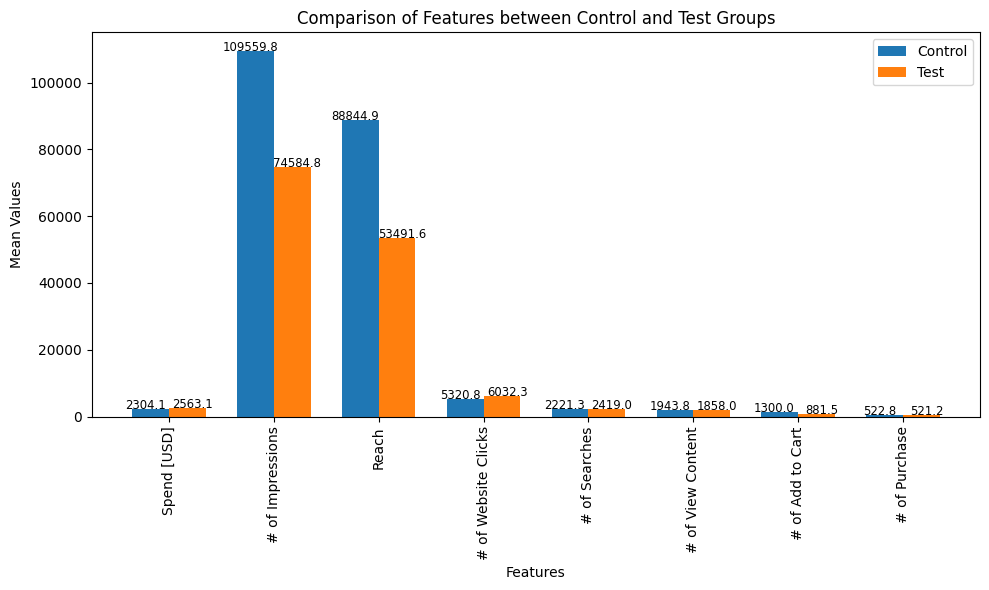

```python
# Features and their indices for the x-axis
features = ['Spend [USD]', '# of Impressions', 'Reach', '# of Website Clicks', '# of Searches', '# of View Content', '# of Add to Cart', '# of Purchase']
len_features = np.arange(len(features))

# Mean values for each feature in control and test groups
control_means = df_control[features].mean()
test_means = df_test[features].mean()

# Bar width
bar_width = 0.35

# Create bar plots
plt.figure(figsize=(10, 6))
bar_control = plt.bar(len_features - bar_width/2, control_means, bar_width, label='Control')
bar_test = plt.bar(len_features + bar_width/2, test_means, bar_width, label='Test')

# Set x-axis labels
plt.xticks(len_features, features, rotation='vertical')

# Set plot labels and title
plt.xlabel('Features')
plt.ylabel('Mean Values')
plt.title('Comparison of Features between Control and Test Groups')
plt.legend()

# Add labels on top of the bars
for bar_control, bar_test in zip(bar_control, bar_test):
    height_control = bar_control.get_height()
    height_test = bar_test.get_height()
    plt.text(bar_control.get_x() + bar_control.get_width()/2 - 0.05, height_control + 0.05, f'{height_control:.1f}', ha='center', fontsize='small')
    plt.text(bar_test.get_x() + bar_test.get_width()/2 + 0.05, height_test + 0.05, f'{height_test:.1f}', ha='center', fontsize='small')

# Show the plot
plt.tight_layout()
plt.show()
```

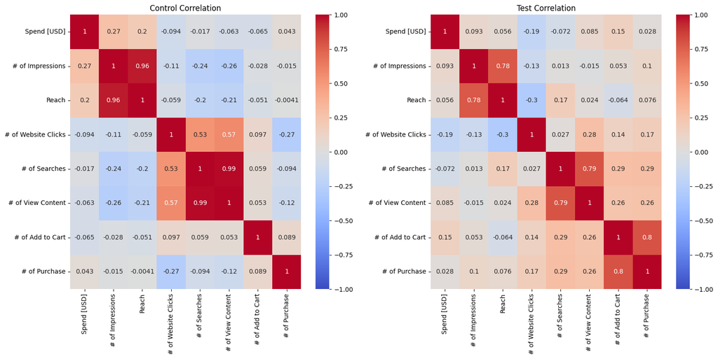

```python
# Correlation matrix
correlation_control = df_control[features].corr()
correlation_test = df_test[features].corr()

# Heatmap
plt.figure(figsize=(16, 8))
plt.subplot(1, 2, 1)
plt.title('Control Correlation')
sns.heatmap(correlation_control, annot=True, cmap='coolwarm', norm=colors.CenteredNorm())

plt.subplot(1, 2, 2)
plt.title('Test Correlation')
sns.heatmap(correlation_test, annot=True, cmap='coolwarm', norm=colors.CenteredNorm())

plt.tight_layout()
plt.show()
```

# 'Spend [USD]'

Question: Does the expenditure significantly differ between the two groups?

```python
# Perform t-test for'Spend [USD]'
control_spend = df_control['Spend [USD]']
test_spend = df_test['Spend [USD]']

t_stat, p_value = ttest_ind(control_spend, test_spend)

# Check if the difference is statistically significant
if p_value < 0.05:
    print("""The difference in 'Spend [USD]' between control and test groups is statistically significant.
             There is sufficient statistical evidence to conclude that the two samples have different means.""")
    print(f"T-stat: {t_stat: .4f}, P-value: {p_value: .4f}")
else:
    print("The difference is not statistically significant.")
    print(f"T-stat: {t_stat: .4f}, P-value: {p_value: .4f}")
```

```
The difference in 'Spend [USD]' between control and test groups is statistically significant.
             There is sufficient statistical evidence to conclude that the two samples have different means.
T-stat: -2.7932, P-value:  0.0071
```

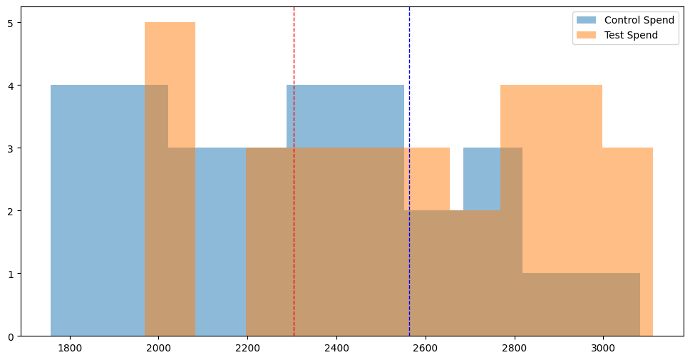

```python
# Visualizing the results
mean_control_spend = np.mean(control_spend)
mean_test_spend = np.mean(test_spend)

plt.figure(figsize=(12, 6))
plt.hist(control_spend, alpha=0.5, label='Control Spend')
plt.hist(test_spend, alpha=0.5, label='Test Spend')
plt.axvline(mean_control_spend, color='r', linestyle='dashed', linewidth=1)
plt.axvline(mean_test_spend, color='b', linestyle='dashed', linewidth=1)
plt.legend(loc='upper right')
plt.show()
```

# '# of Impressions'

Question: Is there a statistically significant impact on the impressions generated by the campaign?

```python
# Perform t-test for'# of Impressions'
control_impressions = df_control['# of Impressions']
test_impressions = df_test['# of Impressions']

t_stat, p_value = ttest_ind(control_impressions, test_impressions)

# Check if the difference is statistically significant
if p_value < 0.05:
    print("""The difference in '# of Impressions' between control and test groups is statistically significant.
             There is sufficient statistical evidence to conclude that the two samples have different means.""")
    print(f"T-stat: {t_stat: .4f}, P-value: {p_value: .4f}")
else:
    print("The difference is not statistically significant.")
    print(f"T-stat: {t_stat: .4f}, P-value: {p_value: .4f}")
```

```
The difference in '# of Impressions' between control and test groups is statistically significant.
             There is sufficient statistical evidence to conclude that the two samples have different means.
T-stat:  4.8845, P-value:  0.0000
```

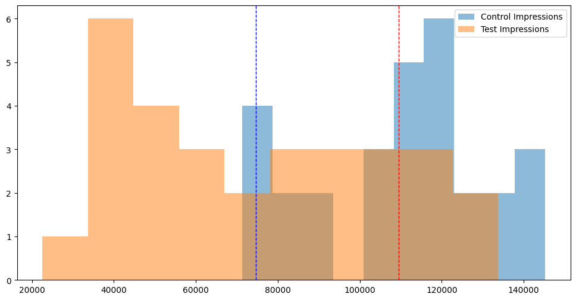

```python
# Visualizing the results
mean_control_impressions = np.mean(control_impressions)
mean_test_impressions = np.mean(test_impressions)

plt.figure(figsize=(12, 6))
plt.hist(control_impressions, alpha=0.5, label='Control Impressions')
plt.hist(test_impressions, alpha=0.5, label='Test Impressions')
plt.axvline(mean_control_impressions, color='r', linestyle='dashed', linewidth=1)
plt.axvline(mean_test_impressions, color='b', linestyle='dashed', linewidth=1)
plt.legend(loc='upper right')
plt.show()
```

# 'Reach'

Question: Does the campaign significantly affect the unique audience reached?

```python
# Perform t-test for'Reach'
control_reach = df_control['Reach']
test_reach = df_test['Reach']

t_stat, p_value = ttest_ind(control_reach, test_reach)

# Check if the difference is statistically significant
if p_value < 0.05:
    print("""The difference in 'Reach' between control and test groups is statistically significant.
             There is sufficient statistical evidence to conclude that the two samples have different means.""")
    print(f"T-stat: {t_stat: .4f}, P-value: {p_value: .4f}")
else:
    print("The difference is not statistically significant.")
    print(f"T-stat: {t_stat: .4f}, P-value: {p_value: .4f}")
```

```
The difference in 'Reach' between control and test groups is statistically significant.
             There is sufficient statistical evidence to conclude that the two samples have different means.
T-stat:  5.3004, P-value:  0.0000
```

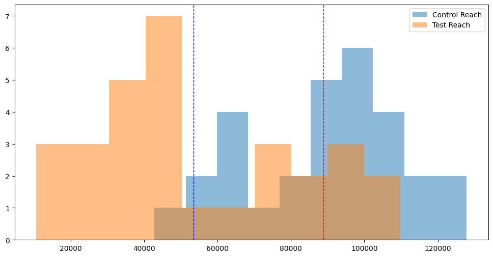

```python
# Visualizing the results
mean_control_reach = np.mean(control_reach)
mean_test_reach = np.mean(test_reach)

plt.figure(figsize=(12, 6))
plt.hist(control_reach, alpha=0.5, label='Control Reach')
plt.hist(test_reach, alpha=0.5, label='Test Reach')
plt.axvline(mean_control_reach, color='r', linestyle='dashed', linewidth=1)
plt.axvline(mean_test_reach, color='b', linestyle='dashed', linewidth=1)
plt.legend(loc='upper right')
plt.show()
```

# '# of Website Clicks'

Question: Is there a significant impact on user engagement through clicks?

```python
# Perform t-test for'# of Website Clicks'
control_website_clicks = df_control['# of Website Clicks']
test_website_clicks = df_test['# of Website Clicks']

t_stat, p_value = ttest_ind(control_website_clicks, test_website_clicks)

# Check if the difference is statistically significant
if p_value < 0.05:
    print("""The difference in '# of Website Clicks' between control and test groups is statistically significant.
             There is sufficient statistical evidence to conclude that the two samples have different means.""")
    print(f"T-stat: {t_stat: .4f}, P-value: {p_value: .4f}")
else:
    print("The difference is not statistically significant.")
    print(f"T-stat: {t_stat: .4f}, P-value: {p_value: .4f}")
```

```
The difference is not statistically significant.
T-stat: -1.5769, P-value:  0.1204
```

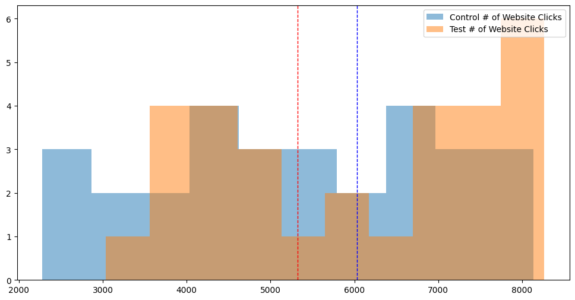

```python
# Visualizing the results
mean_control_website_clicks = np.mean(control_website_clicks)
mean_test_website_clicks = np.mean(test_website_clicks)

plt.figure(figsize=(12, 6))
plt.hist(control_website_clicks, alpha=0.5, label='Control # of Website Clicks')
plt.hist(test_website_clicks, alpha=0.5, label='Test # of Website Clicks')
plt.axvline(mean_control_website_clicks, color='r', linestyle='dashed', linewidth=1)
plt.axvline(mean_test_website_clicks, color='b', linestyle='dashed', linewidth=1)
plt.legend(loc='upper right')
plt.show()
```

# '# of Seaches'

Question: Does the campaign influence user search behavior on the website?

```python
# Perform t-test for'# of Searches'
control_search = df_control['# of Searches']
test_search = df_test['# of Searches']

t_stat, p_value = ttest_ind(control_search, test_search)

# Check if the difference is statistically significant
if p_value < 0.05:
    print("""The difference in '# of Searches' between control and test groups is statistically significant.
             There is sufficient statistical evidence to conclude that the two samples have different means.""")
    print(f"T-stat: {t_stat: .4f}, P-value: {p_value: .4f}")
else:
    print("The difference is not statistically significant.")
    print(f"T-stat: {t_stat: .4f}, P-value: {p_value: .4f}")
```

```
The difference is not statistically significant.
T-stat: -1.1373, P-value:  0.2602
```

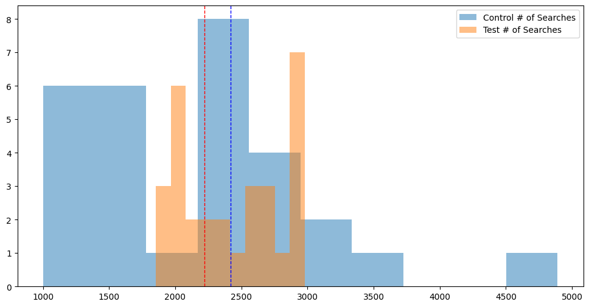

```python
# Visualizing the results
mean_control_search = np.mean(control_search)
mean_test_search = np.mean(test_search)

plt.figure(figsize=(12, 6))
plt.hist(control_search, alpha=0.5, label='Control # of Searches')
plt.hist(test_search, alpha=0.5, label='Test # of Searches')
plt.axvline(mean_control_search, color='r', linestyle='dashed', linewidth=1)
plt.axvline(mean_test_search, color='b', linestyle='dashed', linewidth=1)
plt.legend(loc='upper right')
plt.show()
```

# '# of View Content'

Question: Does the campaign impact user engagement with content and products?

```python
# Perform t-test for'# of View Content'
control_view_content = df_control['# of View Content']
test_view_content = df_test['# of View Content']

t_stat, p_value = ttest_ind(control_view_content, test_view_content)

# Check if the difference is statistically significant
if p_value < 0.05:
    print("""The difference in '# of View Content' between control and test groups is statistically significant.
             There is sufficient statistical evidence to conclude that the two samples have different means.""")
    print(f"T-stat: {t_stat: .4f}, P-value: {p_value: .4f}")
else:
    print("The difference is not statistically significant.")
    print(f"T-stat: {t_stat: .4f}, P-value: {p_value: .4f}")
```

```
The difference is not statistically significant.
T-stat:  0.4762, P-value:  0.6358
```

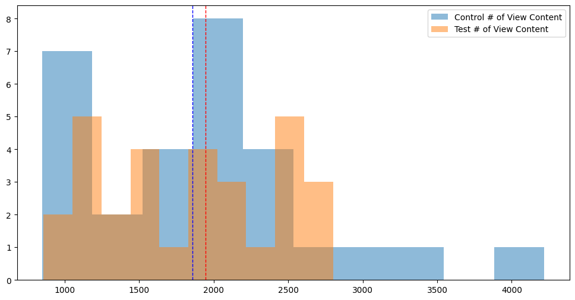

```python
# Visualizing the results
mean_control_view_content = np.mean(control_view_content)
mean_test_view_content = np.mean(test_view_content)

plt.figure(figsize=(12, 6))
plt.hist(control_view_content, alpha=0.5, label='Control # of View Content')
plt.hist(test_view_content, alpha=0.5, label='Test # of View Content')
plt.axvline(mean_control_view_content, color='r', linestyle='dashed', linewidth=1)
plt.axvline(mean_test_view_content, color='b', linestyle='dashed', linewidth=1)
plt.legend(loc='upper right')
plt.show()
```

# '# of Add to Cart'

Question: Does the campaign affect the likelihood of users adding products to their cart?

```python
# Perform t-test for'# of Add to Cart'
control_add_to_cart = df_control['# of Add to Cart']
test_add_to_cart = df_test['# of Add to Cart']

t_stat, p_value = ttest_ind(control_add_to_cart, test_add_to_cart)

# Check if the difference is statistically significant
if p_value < 0.05:
    print("""The difference in '# of Add to Cart' between control and test groups is statistically significant.
             There is sufficient statistical evidence to conclude that the two samples have different means.""")
    print(f"T-stat: {t_stat: .4f}, P-value: {p_value: .4f}")
else:
    print("The difference is not statistically significant.")
    print(f"T-stat: {t_stat: .4f}, P-value: {p_value: .4f}")
```

```
The difference in '# of Add to Cart' between control and test groups is statistically significant.
             There is sufficient statistical evidence to conclude that the two samples have different means.
T-stat:  4.2491, P-value:  0.0001
```

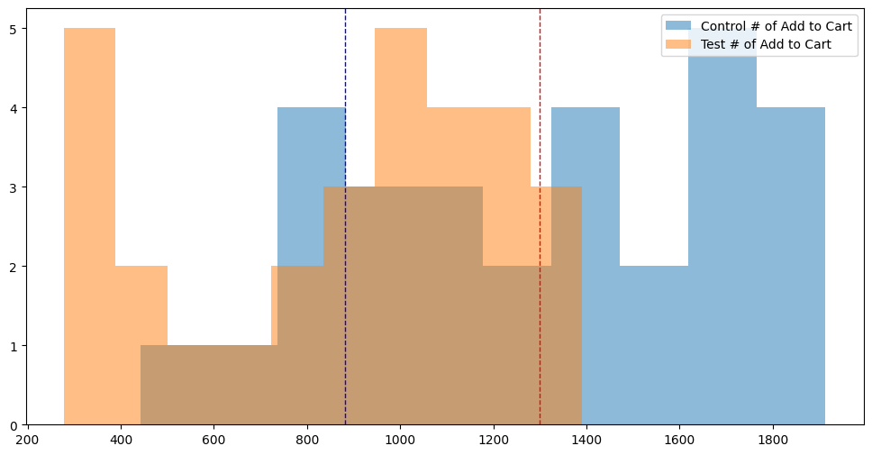

```python
# Visualizing the results
mean_control_add_to_cart = np.mean(control_add_to_cart)
mean_test_add_to_cart = np.mean(test_add_to_cart)

plt.figure(figsize=(12, 6))
plt.hist(control_add_to_cart, alpha=0.5, label='Control # of Add to Cart')
plt.hist(test_add_to_cart, alpha=0.5, label='Test # of Add to Cart')
plt.axvline(mean_control_add_to_cart, color='r', linestyle='dashed', linewidth=1)
plt.axvline(mean_test_add_to_cart, color='b', linestyle='dashed', linewidth=1)
plt.legend(loc='upper right')
plt.show()
```

# '# of Purchase'

Question: Does the campaign lead to a statistically significant increase in purchases?

```python
# Perform t-test for'# of Purchases'
control_purchases = df_control['# of Purchase']
test_purchases = df_test['# of Purchase']

t_stat, p_value = ttest_ind(control_purchases, test_purchases)

# Check if the difference is statistically significant
if p_value < 0.05:
    print("""The difference in '# of Purchase' between control and test groups is statistically significant.
             There is sufficient statistical evidence to conclude that the two samples have different means.""")
    print(f"T-stat: {t_stat: .4f}, P-value: {p_value: .4f}")
else:
    print("The difference is not statistically significant.")
    print(f"T-stat: {t_stat: .4f}, P-value: {p_value: .4f}")
```

```
The difference is not statistically significant.
T-stat:  0.0301, P-value:  0.9761
```

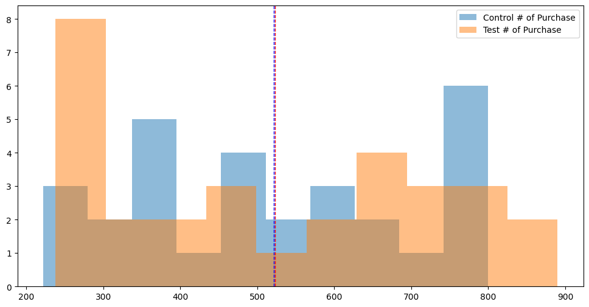

```python
# Visualizing the results
mean_control_purchases = np.mean(control_purchases)
mean_test_purchases = np.mean(test_purchases)

plt.figure(figsize=(12, 6))
plt.hist(control_purchases, alpha=0.5, label='Control # of Purchase')
plt.hist(test_purchases, alpha=0.5, label='Test # of Purchase')
plt.axvline(mean_control_purchases, color='r', linestyle='dashed', linewidth=1)
plt.axvline(mean_test_purchases, color='b', linestyle='dashed', linewidth=1)
plt.legend(loc='upper right')
plt.show()
```

# Potential KPIs

- 'Spend [USD]'
- '# of Impressions'
- 'Reach'
- '# of Add to Cart'